# Johnson-Strother Replication

Jake S. Truscott

2024-06-04

```r
pai <- function(data,
                model = NULL,
                outcome = NULL,
                predictors = NULL,
                interactions = NULL,
                drop_vars = NULL,
                cores = NULL,
                placebo_iterations = NULL,
                folds = NULL,
                train_split = 0.8,
                custom_tc = FALSE,
                assign_factors = 3,
                list_drop_vars = FALSE,
                seed = 1234){...}
```

### **Variables**

- `data` Data object
- `model` Model selected from `caret` CRAN (Ex: ‘parRF’, ‘adaboost’)
- `outcome` Dependent variable of interest
- `predictors` Predictors of interest (defaults to all variables in `data` except `outcome`.)
- `interactions` Interaction term(s) declared as a vector separated by ‘,’ (Ex: c(‘var1*var2’, ‘var3:var4’))
- `drop_vars` Specific variables to drop during omission procedure (defaults to all predictors and interactions)
- `cores` Number of computing cores to allocate (defaults to one)
- `placebo_iterations` Number of placebo (shuffling) interations to run (defaults to 10)
- `folds` Number of K-Folds for `trainControl` in `caret` CRAN (defaults to 5)
- `train_split` Proportion of data for train/test split (Defaults to 0.8 – Indicating 80/20 Split)
- `custom_tc` Custom `trainControl` parameters (For `caret` models that require unique/specific parameters)
- `assign_factors` Automatically assign levels to prescribe factor variables (Defaults to 3 Levels)
- `list_drop_vars` If `TRUE` assigns drop_vars as a group designated by object in global environment (Ex: vars = c(‘var1’, ‘var2’, ‘var3’) and drops them collectively instead of individually.
- `seed` Random seed generator (Defaults to `1234`)

### **Johnson-Strother Replication (The Least Responsive Branch)**

```r
js_test <- pai(data = js,
               model = 'parRF',
               outcome = 'direction',
               predictors = NULL,
               interactions = NULL,
               drop_vars = drop_var_list,
               cores = 8,
               placebo_iterations = 200,
               list_drop_vars = TRUE,
               folds = 10,
               custom_tc = 'repeats = 5',
               seed = 254){...}
```

#### **Diagnostic Output Retrieval**

```r
pai_diagnostic_retrieval <- function(output,
                                     diagnostic,
                                     type,
                                     variables = NULL,
                                     combine_plots = FALSE){...}
```

- `output` PAI Object (ex: `js_test`)
- `diagnostic` PAI sequence to retrieve. Options: `push`, `placebo` (permutations), `bootstrap`, or `summary`.
- `type` Type of diagnostic to retrieve. Options: `figure`, `all` (*placebo only*), `data`, or `distribution` (*bootstrap only*)
- `variables` Vector of variable names to filter diagnostic (ex: `c('var2', 'var3')`). Defaults to *all*
- `combine_plots` If `TRUE`, Returns multi-variable diagnostic figures as a single object using `cowplot` (CRAN).

##### **Placebo Iterations**

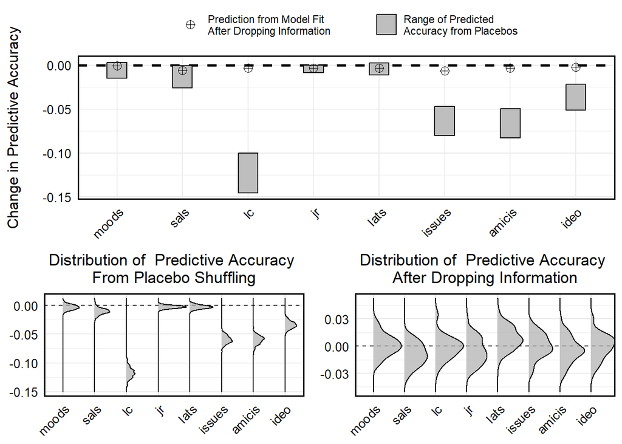

```r
pai_diagnostic_retrieval(output = js_test,
                         diagnostic = 'placebo',
                         type = 'all')
```

*Note*: For continuous vars, change represents change in RMSE. For Binomial terms, it represents predictive accuracy.

##### **Bootstrap Distribution**

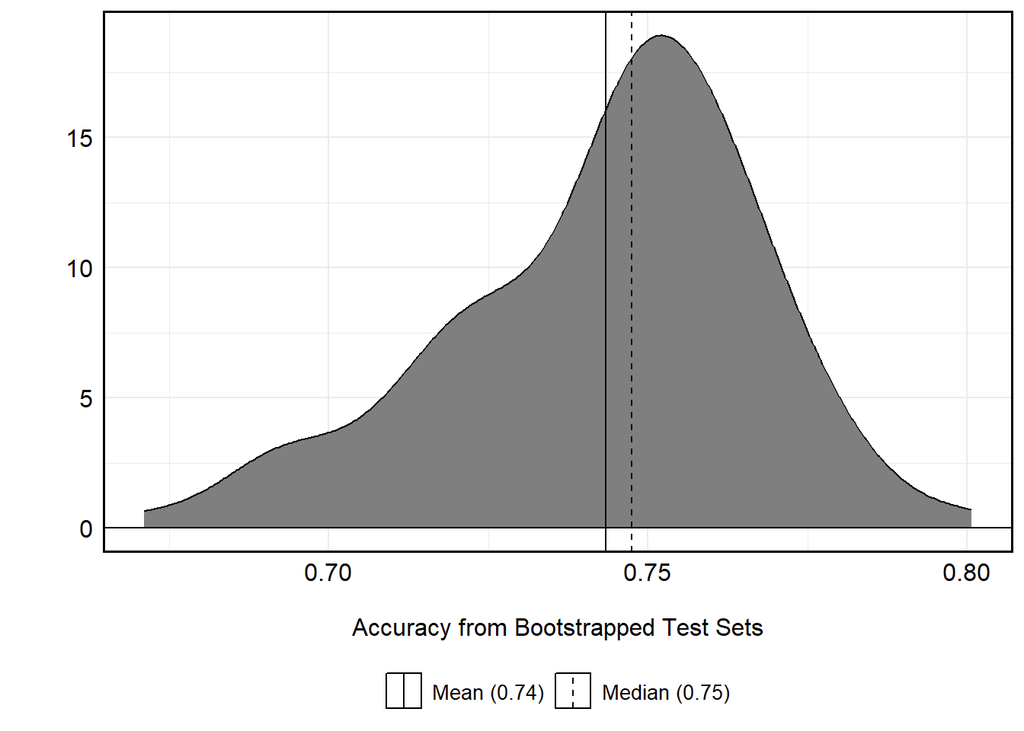

```r
pai_diagnostic_retrieval(output = js_test,
                         diagnostic = 'bootstrap',
                         type = 'distribution',
                         combine_plots = TRUE)
```

##### **Summary Output**

```r
pai_diagnostic_retrieval(output = js_test,
                         diagnostic = 'summary')
```

```
## $`Performance Metrics`
##   mtry  Accuracy     Kappa AccuracySD    KappaSD
## 1    2 0.6371795 0.2764012 0.01432259 0.02785698
## 2  100 0.6893593 0.3787733 0.01066585 0.02128606
## 3  199 0.6874127 0.3748126 0.00969520 0.01931436
##
## $`Variable Importance`
##                                    Importance
## term                               23.0611030
## naturalCourt1407                    4.3488783
## naturalCourt1408                    6.7616638
## naturalCourt1409                    8.0712806
## naturalCourt1410                    3.4181304
## naturalCourt1411                    2.6382379
## naturalCourt1501                    2.6492506
## naturalCourt1502                    2.2264333
## naturalCourt1503                    5.2950054
## naturalCourt1504                    3.3220085
## naturalCourt1505                    3.2508913
## naturalCourt1506                    4.8845504
## naturalCourt1507                    8.4376474
## naturalCourt1601                    7.9770714
## naturalCourt1602                    3.5702767
## naturalCourt1603                    9.8906777
## naturalCourt1604                    5.7061876
## naturalCourt1605                    3.4177428
## naturalCourt1606                    5.9144856
## naturalCourt1607                    7.0042363
## naturalCourt1701                    3.8475420
## naturalCourt1702                    7.5565927
## chiefRehnquist                      8.4607637
## chiefRoberts                        5.0172781
## chiefWarren                        10.5657272
## jurisdiction2                      15.5338005
## jurisdiction4                       3.2508913
## jurisdiction5                      13.8293471
## jurisdiction6                       1.3054415
## jurisdiction7                       3.2508913
## jurisdiction8                       8.7330833
## jurisdiction9                       5.9048948
```

[output cut: 190 more lines]

```
##          Detection Rate : 0.3792
##    Detection Prevalence : 0.5226
##       Balanced Accuracy : 0.7399
##
##        'Positive' Class : 0
##
##
## $Precision
## [1] 0.72554
##
## $Recall
## [1] 0.7643909
##
## $F1
## [1] 0.7444589
```